# Homework 3: Random Variables and Their Distributions

**Name**: Cal Brynestad

This assignment is due on Canvas by **6:00PM on Friday October 22nd**. Your solutions to theoretical questions should be done in Markdown directly below the associated question. Your solutions to computational questions should include any specified Python code and results as well as written commentary on your conclusions. Remember that you are encouraged to discuss the problems with your classmates, but **you must write all code and solutions on your own**.

**NOTES**:

- Any relevant data sets should be available in the Homework 03 assignment write-up on Canvas. To make life easier on the grader if they need to run your code, do not change the relative path names here. Instead, move the files around on your computer.
- If you're not familiar with typesetting math directly into Markdown then by all means, do your work on paper first and then typeset it later. Remember that there is a [reference guide](https://math.meta.stackexchange.com/questions/5020/mathjax-basic-tutorial-and-quick-reference) linked on Canvas on writing math in Markdown. **All** of your written commentary, justifications and mathematical work should be in Markdown.
- Because you can technically evaluate notebook cells is a non-linear order, it's a good idea to do Kernel $\rightarrow$ Restart & Run All as a check before submitting your solutions. That way if we need to run your code you will know that it will work as expected.
- It is **bad form** to make your reader interpret numerical output from your code. If a question asks you to compute some value from the data you should show your code output **AND** write a summary of the results in Markdown directly below your code.
- This probably goes without saying, but... For any question that asks you to calculate something, you **must show all work and justify your answers to receive credit**. Sparse or nonexistent work will receive sparse or nonexistent credit.

```python
import pandas as pd
import numpy as np
from math import factorial
import matplotlib.pylab as plt
from scipy.special import binom
from scipy.stats import poisson
%matplotlib inline
```

### [20 points] Problem 1

Suppose you are modeling the probability of observing flood levels of various heights when there is a storm in a particular coastal city. Let $X$ be a random variable representing the observed flood height (in feet), which must be nonnegative. There are many different choices for probability density function (pdf) for $X$, but as the tide oscillates up and down, you decide to use the following pdf for $X$:

$$ f(x) = \begin{cases} a \ |\sin(x)| & 0 \leq x < 2\pi \\ 0 & \text{otherwise} \end{cases} $$

where $a$ is some normalizing constant.

**Part A**: Determine the value of $a$ such that $f(x)$ is a valid density function.

$\color{red}{\text{Solution to Part A here}}$

**Solution**: We want a value for a such that: $\int_{0}^{2\pi} a |\sin(x)| dx = 1$  
$\int_{0}^{2\pi} a |\sin(x)| dx = \int_{0}^{\pi} a \sin(x) dx + \int_{\pi}^{2\pi} a (-\sin(x)) dx = a \int_{0}^{\pi} \sin(x) dx - a \int_{\pi}^{2\pi} \sin(x) dx$  
$= a[-\cos(\pi) - (-\cos(0))] - a[-\cos(2\pi) - (-\cos(\pi))]$  
$= a[(1 - (-1))] - a[(-1 -(1))] = 2a - (-2a) = 4a$  
We set $4a = 1$ and get $a = \frac{1}{4}$

**Part B**: Compute the cumulative density (cdf) function $F(x)$ for $X$.

Then, conduct two sanity checks: First, what should $F(0)$ equal? Second, what should $F(2\pi)$ equal? Does your cdf function have the correct values for $F(0)$ and $F(2\pi)$? Be sure to **justify** these answers.

$\color{red}{\text{Solution to Part B here}}$

**Solution**:
If a is less than or equal to $\pi$, then $F(a) = \frac{1}{4} \int_{0}^{a} \sin(x) dx = \frac{1}{4} (-\cos(a) - (-\cos(0))) = \frac{1}{4}(-\cos(a) + 1)$
If a is greater than $\pi$, then $ F(a) = \frac{1}{4} \int_{0}^{\pi} \sin(x) dx + \frac{1}{4} \int_{\pi}^{a} (-\sin(x)) dx = \frac{1}{2} - \frac{1}{4} \int_{\pi}^{a} \sin(x) dx = \frac{1}{2} - \frac{1}{4}(-\cos(a) - (-\cos(\pi))) = \frac{1}{2} - \frac{1}{4}(-\cos(a) - 1)$
Formally:
$$ F(a) = \begin{cases} \frac{1}{4}(-\cos(a) + 1) & 0 \leq a \leq \pi \\ \frac{1}{2} - \frac{1}{4}(-\cos(a) - 1) & \pi < a \leq 2\pi \end{cases} $$
$F(0)$ should equal 0 and $F(2\pi)$ should equal 1.
Using our cdf above:
$F(0) = \frac{1}{4}(-\cos(0) + 1) = \frac{1}{4}(-1 + 1) = 0$
$F(2\pi) = \frac{1}{2} - \frac{1}{4}(-\cos(2\pi) - 1) = \frac{1}{2} - \frac{1}{4}(-1 - 1) = \frac{1}{2} - \frac{1}{4}(-2) = \frac{1}{2} + \frac{2}{4} = 1$
Therefore, the cdf function has the correct values for $F(0)$ and $F(2\pi)$. $F(0) = 0$ makes sense as this is computing the area of nothing and $F(2\pi) = 1$ makes sense as this is computing the area underneath the entirety of the probability density function.

**Part C:** Use the cdf you derived in **Part B** to calculate the median, $\tilde{x}$, of the probability density for $X$.

$\color{red}{\text{Solution to Part C here}}$

**Solution:**  
The median of the probability density for X is the point where half the area under the curve is to the right of the point and half of the area is to the left. Using our cdf we can find this point as follows:  
$F(a) = \frac{1}{2}$  
$\frac{1}{4}(-\cos(a) + 1) = \frac{1}{2}$  
$-\cos(a) + 1 = 2$  
$-\cos(a) = 1$  
$\cos(a) = -1$  
$-\cos^{-1}(1) = a = \pi$  
So, the median, $\tilde{x}$, of the probability density for $X$ is $\pi$.

**Part D**: Use the cdf you computed in **Part B** to find the probability that a given storm will produce flood levels that exceed 4 feet. Give your answer to the nearest 4 decimals.

$\color{red}{\text{Solution to Part D here}}$

**Solution**: $1 - F(4) = 1 - (\frac{1}{2} - \frac{1}{4}(-\cos(4) - 1)) = 1 - (\frac{1}{2} - \frac{1}{4}(-.3463563791))$  
$= 1 - (\frac{1}{2} + .0865890948) = 1 - (.5865890948) = .4134109052$  
The probability that a given storm will produce flood levels that exceed 4 feet is 41.3411%

**Part E:** You have been painstakingly collecting data on storms in your city, and have determined that storms occur at an average rate of 5 per year. To makes things a bit more precise, the pdf from **Part A** really describes the distribution of flood heights *given* that there is a storm, $P(X \mid \text{storm})$. You may assume that storms occur as independent events of one another.

What is the probability of observing 3 storms in a given year, none of which produce flood levels that exceed 4 feet?

That is, what is $P(3 \ \text{storms producing flood levels under 4 feet} \cap 3 \text{ storms})$?

$\color{red}{\text{Solution to Part E here}}$

**Solution**: The probability that there will be 3 storms in a given year is:  
$P(3 storms) = \frac{5^3 \cdot e^{-5}}{3!} = .1403738958$  
The probability that there are 3 storms each producing flood levels below 4 feet, given that there are 3 storms is:  
$P(3 below 4 | 3 storms) = F(4)^3 = (.5866)^3 = .2018488019$  
So, $P(3 \ \text{storms producing flood levels under 4 feet} \cap 3 \text{ storms})$  
$= P(\text{3 storms}) \cdot P(\text{each of the 3 storms are under 4 feet}) = .1404 \cdot .2018 = .028332$ or 2.8332%

### [20 points] Problem 2

You are waiting in line at the grocery store. It is taking *forever*! There are only two lines open; one is being tended by a cashier named John Henry), and the other is tended by a [self check-out machine](https://theconversation.com/the-economics-of-self-service-checkouts-78593). Like all human beings when they arrive at the front of the store to check-out and encounter lines everywhere, you first experience a moment of intense panic. *Which line will be the fastest?* you wonder, as people shuffle around you.

You decide you need to model the arrival of customers at the front of each of the lines. From your Intro to Data Science class you remember that the distribution of times *between* independent arrivals is often modeled using an Exponential distribution. You observe the following:

- John's line checks-out an average of 4 customers per ten minutes,
- the self check-out machine checks-out an average of 5 customers per ten minutes **if** the machine is working properly,
- the self check-out machine checks-out an average of 1 customer per ten minutes if the machine is freezing up, and
- in any given moment, the self check-out machine has a probability of 0.1 of freezing up.

Answer the following questions about this scenario. **Note** that for **Parts B-D** you should clearly express the computation you're doing with math, but feel free to do any fancy function evaluations with Python.

**Part A**: Assuming the between-customer times do in fact follow exponential distributions, what distributions do you expect the **number** of customers who pass through each line in a given 10-minute interval to follow? What are the parameter(s) of each distribution? Note that you should consider both the case where the self check-out is working properly and when it is broken.

$\color{red}{\text{Solution to Part A here}}$

**Solution**:  
The number of customers who pass through a line in a given 10-minute interval should follow a Poisson distribution, for each of the different lines.  
For John's line: $\mu = 4$  
For self check-out line when it is working: $\mu = 5$  
For self check-out line when it is not working: $\mu = 1$

**Part B**: What is the probability that 6 customers pass through John's line in the next 10 minutes? What about the self check-out, assuming that it is working? What about the self check-out, assuming that it is frozen?

$\color{red}{\text{Solution to Part B here}}$

**Solution**:  
For John's line:  
$P(X=6) = \frac{4^6 \cdot e^{-4}}{6!} = .10419$  
For working self checkout:  
$P(X=6) = \frac{5^6 \cdot e^{-5}}{6!} = .14622$  
For non working self checkout:  
$P(X=6) = \frac{1^6 \cdot e^{-1}}{6!} = .0005109$

**Part C:** Use your answer to **Part B** and the Law of Total Probability to calculate the probability that the self check-out tends 6 customers is the next 10 minutes.

$\color{red}{\text{Solution to Part C here}}$

**Solution:**  
P(6 in 10) = P(6 customers are checked out | self CO is working) $\cdot$ P(self CO is working) + P(6 customers are checked out | self CO is not working) $\cdot$ P(self CO is not working)  
$= (.14622) \cdot (.9) + (.0005109) \cdot (.1) = .13164909$ or 13.1649%

**Part D**: S'pose John is working a 5-hour shift from 4-9 PM after school. He gets no breaks, because the year is 1870 and worker's rights is not yet a thing. Calculate **exactly** (aside from rounding) the probability that he serves 100 or more customers during his shift. (Assume we can safely scale our data up to a 5-hour interval.)

$\color{red}{\text{Solution to Part D here}}$

**Solution:**  
$P(x \geq 100) = 1- P(x \leq 99)$  
$F(99) = P(x \leq 99) = \sum_{i=0}^{99} \frac{\mu^{i} \cdot e^{-\mu}}{i!} = e^{-\mu}\sum_{i=0}^{99} \frac{\mu^{i}}{i!} = e^{-120}\sum_{i=0}^{99} \frac{120^{i}}{i!}$

```python
prob = poisson.cdf(99, 120)

final = 1 - prob

print("The probability that he serves 100 or more customers during his shift is ",final)
```

```
The probability that he serves 100 or more customers during his shift is  0.9721362601094794
```

**Part E**: Write a function `checkout_count` to simulate the number of customers served by the self check-out machine in a 5-hour shift. At the very least, your function should take as input the working and broken customer arrival rate parameters, and the probability that the machine is working properly. Your simulation should model the arrival of each new customer, and sample whether or not the machine is working properly for each new customer. Then, your function should simulate customer arrival times at the front of the line by sampling between-customer times from $Exp(\lambda)$ via Numpy's [random.exponential](https://docs.scipy.org/doc/numpy-1.13.0/reference/generated/numpy.random.exponential.html) function, where the argument $\lambda$ will depend on the state of the machine (working or broken). Your function should return the number of customer arrivals in a 5-hour shift. Use at least 5000 simulations.

Use this function to estimate the probability of the self check-out machine serves 100 or more customers in a 5-hour shift, and report your result.

Finally, use **this same function**, to verify your answer to **Part D**.

**Caution!** Be aware that in some Numpy or Scipy functions for distribution and/or random variables, the conventions for the parameter arguments may differ from those used in class.

$\color{red}{\text{Solution to Part E here}}$

**Solution:**

```python
def checkout_count(mu1, mu2, works):
    customers = 0
    timeTotal = 0

    while timeTotal < 1:
        works = np.random.choice([0,1], p = [1-works, works])

        if works == 0:
            mu = mu2
            time = np.random.exponential(1/mu)
            customers+=1

        else:
            mu = mu1
            time = np.random.exponential(1/mu)
            customers+=1

        timeTotal = timeTotal + time

    return customers


success = 0
for i in range(5000):
    customerCheck = checkout_count(150, 30, .9)
    if customerCheck >= 100:
        success += 1

print("The probability that the self check-out machine serves 100 or more customers in a 5-hour shift is approximately ", success/5000)

success = 0
for i in range(5000):
    customerCheck = checkout_count(120, 120, 1)
    if customerCheck >= 100:
        success += 1

print("The probability that John serves 100 or more customers in a 5-hour shift is approximately ",success/5000)
```

```
The probability that the self check-out machine serves 100 or more customers in a 5-hour shift is approximately  0.9026
The probability that John serves 100 or more customers in a 5-hour shift is approximately  0.9774
```

**Part F:** Comment on the results you found in **Part E** for the probabilities that John and the self check-out machine will serve 100 or more customers in a 5-hour block. Which seems like a better investment for the grocery store?

$\color{red}{\text{Solution to Part F here}}$

**Solution:**  
The probability that John serves 100 or more customers in a 5-hour shift was confirmed. This probability is around 97%. On the other hand, the probability that the self check-out machine serves 100 or more customers in a 5-hour shift is slightly lower and seems to be approximately 90%. Therefore, the human has defeated the robot! It seems that John is the better investment for the grocery store.

### [20 points] Problem 3

Well. They're back at it. Luna and her cousin are honing their cinnamon stick skills, and this time they've got a *new* tournament format. (They wouldn't have had to switch formats, but you figured out all the probabilities for their previous tournament format two weeks ago, so this is on you.)

The new format is a *Best-of-9 Series* of individual duels. The first person to win 5 duels is declared the winner. Each duel can be considered to be independent of all previous duels. Moreover, a rigorous statistical analysis of Luna's and her cousin's strengths, weaknesses, and handwriting, has revealed that Luna has an edge: the probability that Luna wins any one duel against her cousin is given by $p=0.76$.

**Part A**: What is the probability that Luna wins the 9-duel series on the 8th duel?

$\color{red}{\text{Solution to Part A here}}$

**Solution**:  
This follows a negative binomial distribution where r = 5 and k = 8:  
$P(X=8) = {(8-1) \choose (5-1)} \cdot (.76)^4 \cdot (.24)^3 \cdot (.76) = {7 \choose 4} \cdot (.76)^4 \cdot (.24)^3 \cdot (.76) = .1226788598$

**Part B**: What is the probability that Luna wins the 9-duel series in *any* valid number of duels?

$\color{red}{\text{Solution to Part B here}}$

**Solution**:  
P(Win) = $\sum_{k=5}^{9} {k-1 \choose 4} p^5 \cdot (1-p)^{k-5} = .9584 $ for p = .76

```python
p = .76
r = 5
n = 9

probs = np.array([binom(k - 1, r - 1) * (p**r) * ((1-p)**(k-r)) for k in range(r, n+1)])

print("The probability that Luna wins the 9-duel series in any valid number of duels is ", np.sum(probs))
```

```
The probability that Luna wins the 9-duel series in any valid number of duels is  0.9584496876991283
```

**Part C**: The winner of the tournament will take home \$10,000. Because the stakes are so high, Luna has decided to hire a famous cinnamon stick consultant, Aishwarya, to help her prepare for each duel.

With Aishwarya's help, Luna's probability of winning any given match increases to $p = 0.85$. Aishwarya charges a fee of $\$90$ per game, but as a testament to her confidence in her abilities, only charges Luna the \$90 for games that she wins and *only if Luna wins the whole tournament*. So, if Luna competes in a 9-duel tournament and wins, she will take home $\$10,000$ _minus_ $\$450$ for Aishwarya's fees, for a total payout of $\$9,550$. What is the expected payout for a 9-duel series?

$\color{red}{\text{Solution to Part C here}}$

**Solution**: P(Win) = $\sum_{k=5}^{9} {k-1 \choose 4} p^5 \cdot (1-p)^{k-5} = .9944 $ for p = .85  
$E[\text{payout}] = \text{payout} \cdot \text{probability of winning payout} = .9944 \cdot 9550 = 9496.52 \text{ dollars}$

```python
p = .85
r = 5
n = 9

probs = np.array([binom(k - 1, r - 1) * (p**r) * ((1-p)**(k-r)) for k in range(r, n+1)])

print("The probability that Luna wins the 9-duel series in any valid number of duels is ", np.sum(probs))
```

```
The probability that Luna wins the 9-duel series in any valid number of duels is  0.9943713368945312
```

**Part D**: This year the Cinnamon Stick Rules Association (the CS Rules Assoc) is implementing an experimental rule: Since Luna is rumored to be the stronger duelist, she gets to *choose* the length of the championship tournament! Specifically, she can choose the series to be any odd length, from $N=3, 5, 7 \dots, 99$ duels long. Assuming that Luna continues to use the service of Aishwarya, and considering the fact that Luna has a better-than-even chance of winning each duel, explain the trade-offs between choosing a short series vs. a long series in terms of Expected Payout.

$\color{red}{\text{Solution to Part D here}}$

**Solution**:  
If Luna chooses a short series, for example a series of 1, luna has an 85% chance of winning the series, given that the proability that she wins a given match is .85, and she'll get to keep $\$9,910$ dollars as Aishwarya's fee for winning 1 match is $\$90$. As serie's lengths get larger and larger, Luna's probability of winning the series get's bigger and bigger as she has the clear advantage given her probability of winning a match is .85. As we saw earlier, the probability Luna wins a 9 duel series is .9944, however for this larger series, Luna now has to pay Aishwarya $\$450$ so her payout is $\$9,550$. So, we can see that if Luna chooses a shorter series she wins more money but is less likely to win. If Luna choosees a longer series, she wins less money but is more likely to win. It is likely that a series of 1 doesn't optimize expected payout and ofcourse neither does a 99 game series. The best series lenght for expected payout is likely somewhere in the middle that balances payout and Luna's win probability.

**Part E**: Write a function `optimal_series` that takes in $p$, the probability that Luna wins an individual duel, then computes the Expected Payout for each series of length $N=3, 5, 7, \ldots 99$ and returns the optimal series length. In addition to returning the optimal series length, your function should also produce a plot of Expected Payout vs Series Length. You may write any additional helper functions that you like, but you should not change the API for the function optimal_series.

```
The optimal series length is 7
```

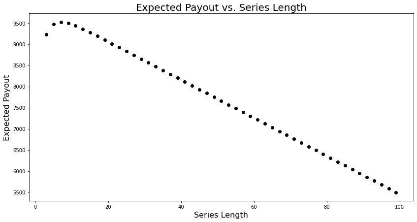

```python
def optimal_series(p):
    pWins = []
    for n in range(3, 100):
        if n % 2 == 1:
            rr = n/2 + .5
            r = int(rr)

            probs = np.array([binom(k - 1, r - 1) * (p**r) * ((1-p)**(k-r)) for k in range(r, n+1)])

            pWin = np.sum(probs)

            pWins.append(pWin)

    i = 2
    payouts = []
    currMax = 0
    bestSeries = 0

    for x in pWins:
        payout = x * (10000 - (90*i))

        if payout > currMax:
            currMax = payout
            bestSeries = (i*2) - 1

        payouts.append(payout)
        i+=1


    optimal_series_length = bestSeries # Placeholder value to be replaced by you

    xcoords = []
    for x in range(3,100):
        if x % 2 == 1:
            xcoords.append(x)

    fig, ax = plt.subplots(figsize=(14,7))
    ax.plot(xcoords, payouts, 'o', color = 'black')
    ax.set_title("Expected Payout vs. Series Length", fontsize=20)
    ax.set_xlabel("Series Length", fontsize=16)
    ax.set_ylabel("Expected Payout", fontsize=16)





    return optimal_series_length

print("The optimal series length is", optimal_series(0.85))
```

### [20 points] Problem 4 - Monte Carlo Estimation of Definite Integrals

One really cool application of random variables is using them to approximate integrals/area under a curve. This method of approximating integrals is used frequently in computational science to approximate really difficult integrals that we never want to do by hand. In this exercise you'll figure out how we can do this in practice and test your method on a relatively simple integral.

**Part A.** Consider the following function.

$$ f(x) = \frac{1}{4} \ \sin(x) $$

Compute **by hand**, the integral of $f(x)$ for $0 \leq x \leq 2$. Once you have your expression worked out, you may use python to estimate the integral to the nearest 6th decimal place.

$\color{red}{\text{Solution to Part A here}}$

**Solution:**  
$\int_{0}^{2} \frac{1}{4} \sin(x) dx = \frac{1}{4} \int_{0}^{2} \sin(x) dx = \frac{1}{4}(-\cos(2) - (-\cos(0))) = \frac{1}{4} (-\cos(2) + 1) = .3540367091$

```python
import scipy.integrate as integrate
import scipy.special as special

result = integrate.quad(lambda x: np.sin(x) * .25, 0, 2)

print("The integral is {:.6f}".format(result[0]))
```

```
The integral is 0.354037
```

**Part B.** Suppose we sample a random variable $X$ from $U(0,2)$ and another random variable $Y$ from $U(0,1)$ and think of them as $x$- and $y$-coordinates of a point in the box $[0,2] \times [0,1]$. If we compute the ratio of points that fall under the curve $f(x)$ to the total points sampled, what does this value estimate?

$\color{red}{\text{Solution to Part B here}}$

**Solution:**  
This value estimates the percentage or fraction of the box that is underneath f(x).

**Part C.** How could we modify the process outlined in **Part B** so that our estimator estimates the value of the desired integral? If you need inspiration, check out the in-class notebook on Stochastic Simulation (#4), specifically, the exercise where we estimated $\pi$!

$\color{red}{\text{Solution to Part C here}}$

**Solution:**  
Instead of computing the ratio of points that fall under the curve $f(x)$ to the total points sampled, we should take the percentage or fraction of points that fell underneath $f(x)$ and multiply it by the area of the square, 2. This would give us the value of the desired integral.

**Part D.** Complete the function `integrate` below to compute an approximation to the definition integral $\int_0^{\text{ub}} f(x)dx$. Your function should take as arguments:

1. `num_samples` -- the number of points to sample,
2. `ub` -- a number between $0$ and $\pi$, and
3. `isPlot` -- a Boolean flag for whether or not to display a plot of the results.

Your function should return an approximation of the definite integral by sampling $X$ from $U(0,\text{ub})$ and $Y$ from $U(0,1)$. For each random draw $(X,Y)$, define the random variable $Z$ that represents whether or not the sampled $Y$ value is less than $f(X)$ for the corresponding $X$ value.

Your function should perform three tasks:

1. return the estimate of the value of the integral,
2. return the sample variance of the random variable $Z$ being simulated, using the np.var function, and
3. if `isPlot` is True, plot the curve $f(x)$ as well as the location of the points $(X,Y)$, colored according to whether they fall above or below the curve.

```
The estimate of the value of the integral is 0.3662
The sample variance of the random variable  𝑍  being simulated is 0.14957439
```

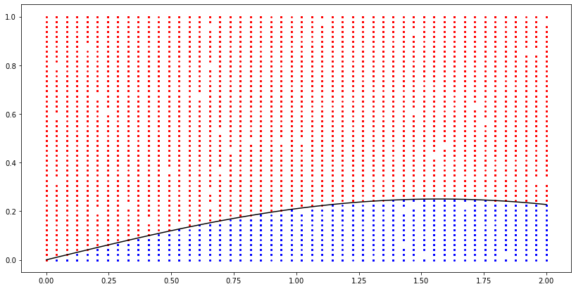

```python
def integrate(num_samples, ub, isPlot):
    xVals = np.linspace(0, ub)

    xValues = []
    for i in range(num_samples):
        x = np.random.choice(xVals)
        xValues.append(x)

    yVals = np.linspace(0, 1)

    yValues = []
    for i in range(num_samples):
        y = np.random.choice(yVals)
        yValues.append(y)


    varList = []
    aboveX = []
    aboveY = []
    belowX = []
    belowY = []
    hits = 0
    i = 0
    for x in xValues:
        height = np.sin(x) * .25
        sameY = yValues[i]
        if sameY < height:
            hits += 1
            belowX.append(x)
            belowY.append(sameY)
            varList.append(1)
        else:
            aboveX.append(x)
            aboveY.append(sameY)
            varList.append(0)
        i+=1


    ratio = hits/num_samples
    sqArea = ub
    integral = ub * ratio


    var = np.var(varList)


    sinX = []
    for x in xVals:
        y = np.sin(x) * .25
        sinX.append(y)


    if isPlot == True:
        fig, ax = plt.subplots(figsize=(14,7))
        ax.scatter(belowX, belowY, s=3, color="blue")
        ax.scatter(aboveX, aboveY, s=3, color="red")
        ax.plot(xVals, sinX, color = "black")

    return (integral,var)


answer = integrate(10000, 2, True)

print("The estimate of the value of the integral is", answer[0])
print("The sample variance of the random variable  𝑍  being simulated is", answer[1])
```

**Part E.** Write your own small unit tests!

First, what should your `integrate` function output if you plug in `ub=0`? Set that as `int_0_to_0` below.

Second, what should your `integrate` function output if you plug in `ub=pi`? Set that as `int_0_to_pi` below.

Then, you can execute the cell below to run two sanity checks. Write out **in math** (like, a definite integral) what each of these two tests is checking and **why** that is a reasonable sanity check.

If these two assertions run without fail, then things seem to be working okay. Note that the upper endpoint test is stochastic, so if it fails, try running it a few times. If it fails a lot, then things are probably going wrong.

```python
# Part E solution here
import math

int_0_to_0 = integrate(10000, 0, False)
print("For upper bound of 0, the integral and variance respectively are", int_0_to_0)

int_0_to_pi = integrate(10000, math.pi, False)
print("For upper bound of pi, the integral and variance respectively are", int_0_to_pi)
```

```
For upper bound of 0, the integral and variance respectively are (0.0, 0.0)
For upper bound of pi, the integral and variance respectively are (0.5136503988619312, 0.13676775)
```

Sanity Check:  
$\int_{0}^{0} \frac{1}{4} \sin(x) dx = \frac{1}{4} \int_{0}^{0} \sin(x) dx = \frac{1}{4}(-\cos(0) - (-\cos(0)) = \frac{1}{4}(-1 - (-1)) = \frac{1}{4}(0) = 0$  
$\int_{0}^{\pi} \frac{1}{4} \sin(x) dx = \frac{1}{4} \int_{0}^{\pi} \sin(x) dx = \frac{1}{4}(-\cos(\pi) - (-\cos(0)) = \frac{1}{4}(1 - (-1)) = \frac{1}{4}(2) = \frac{1}{2}$  
This sanity check has succeeded. The first integral is checking if the integral from 0 to 0 is zero, which should always be the case. The second sanity check is checking if the integral from 0 to pi is one half, which our simulation matched. These are good sanity checks as we know what these integrals are so our simulation either succeeds and comes up with the right values or it does not.

**Part F.** Run your simulation with `isPlot=True` and `ub=2` for 1,000 samples so we can see your plot. Then, run your simulation (with `isPlot=False`) with at least 10,000 samples and estimate the value of the given integral. Be sure to leave your cells evaluated for the graders! Does your estimate agree with the exact value of the integral you computed in **Part A**?

```
The estimate of the value of the integral is 0.3548
The sample variance of the random variable  𝑍  being simulated is 0.14592924
```

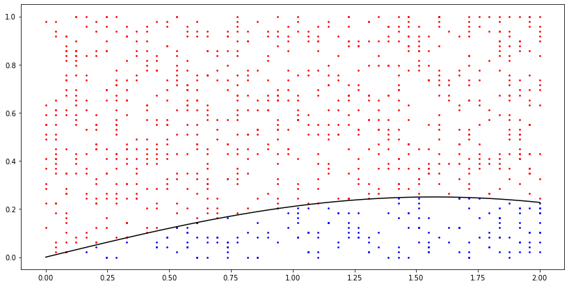

```python
# Part F solution here
integrate(1000, 2, True)
result = integrate(10000, 2, False)
print("The estimate of the value of the integral is", result[0])
print("The sample variance of the random variable  𝑍  being simulated is", result[1])
```

The estimate of the value of the integral does agree with the exact value of the integral that was computed in part A.

### [20 points] Problem 5 - Probabilities and the Normal Distribution

You bring many donuts to work to share with your coworkers at the Boulder Nuclear Power Planet. But due to the high levels of radiation there, they must be inspected for safety. In particular, if the mean level of radiation in a sample from your batch of donuts is above [190 mSv (millisievert)](https://en.wikipedia.org/wiki/Sievert), then they are deemed unsafe and you must throw the whole batch away.

You know that historically donuts at the power plant have, on average, 178 mSv of radiation, with a standard deviation of 65 mSv. For the test (to see if the donuts must be thrown away) you take the donut receipt and pick every fifth donut off it, and sample the radiation levels of those donuts. Assume you bought 245 donuts.

**Part A:** What type of sample is this? What is the sample and what is the size of it? What is the sample space?

$\color{red}{\text{Solution to Part A here}}$

**Solution:**  
This is a systematic sample. The sample is donuts of which there are 49, so size of the sample is 49. The sample space $\Omega$ is all possible levels of radiation of the donuts measured in millisievert.

**Part B:** What is the probability that a donut batch is deemed unsafe? You should at the very least set up and justify your calculation by hand (in Markdown/Mathjax), before executing any calculations in Python. But feel free to use python to actually do the calculations. You *should* use Python to retrieve critical values of a standard normal random variable (using a Z chart is so old school!).

$\color{red}{\text{Solution to Part B here}}$

**Solution:**  
$\mu = 178$, $\sigma = 65$, $x = 190$, $n = 49$, $z = \frac{190 - 178}{\frac{65}{\sqrt{49}}} = 1.2923$  
$P(\text{batch is above 190mSv}) = 1 - P(z \leq 1.2923) = .098$

```python
import scipy.stats as stats

1 - stats.norm.cdf(1.2923)
```

```
0.09812663598702431
```

**Part C.** Yikes! Seems like those donuts might be dangerous, but you really do not want to throw away donuts that frequently, so you propose to store the donuts in a lead-lined donut box. But lead also is not very good for your health, so you are motivated to use the least amount of lead possible. What is the maximum mean amount of radiation $\mu$ for our donuts to have such that the probability that we will throw donuts out due to safety concerns is at most 0.02?

Calculate this **by hand**, using Python only to perform arithmetic operations and compute critical values of a standard normal random variable.

$\color{red}{\text{Solution to Part C here}}$

**Solution:**  
$z_{.02}$ is the 98th percentile  
$z = \frac{x - \mu}{\frac{\sigma}{\sqrt{49}}} \to 2.053748 = \frac{x - 178}{\frac{65}{7}} = 197.07$

```python
stats.norm.ppf(.98)
```

```
2.0537489106318225
```

**Part D.** Your supervisor at the plant decides that serving up donuts in a lead-lined box is a bad idea. Fair enough.

But she is still imposing the requirement that the probability of a batch of donuts being rejected must be less than 0.02. However, she knows a different bakery that might be the solution. At Johnny's Super Consistent Baked Goods Emporium all the donuts are exactly the same in size, which means they are closer to being exactly the same in radiation content (less deviation). Suppose the mean and sample size remain unchanged. What is the largest standard deviation to satisfy this requirement?

Calculate this **by hand**, using Python only to perform arithmetic operations and compute critical values of a standard normal random variable.

$\color{red}{\text{Solution to Part D here}}$

**Solution:**  
$z = \frac{x - \mu}{\frac{\sigma}{\sqrt{49}}} \to 2.053748 = \frac{190 - 178}{\frac{\sigma}{7}} \to \frac{14.376236}{\sigma} = 12 \to \sigma = 1.198$

**Part E.** Can you think of any potential issues with using a normal distribution to model the radiation content of our donuts? Think about a really wide standard deviation, and a way smaller mean (say $\mu = 2$).

$\color{red}{\text{Solution to Part E here}}$

**Solution:**

If $\mu = 2$ and we have a wide standard deviation, say 2, then 1 standard deviation to the left of the mean brings us to 0 mSv. This would mean that any data lying more than one standard deviation to the left of the mean is representative of negative mSv which is impossible. So, this data is irrelevant and can be disregarded. This is not necessarily a problem however. It just means that we should only take into account data that's in between 1 standard deviation to the left of the mean and data that's to the right of that point.